# Communication Data Findings Project

The **Communication Data Findings Project** as a part of the **Udacity Adanced Data Analyst Nano-Degree Program** is focusing on **exploratory data visualization** and **explanatory data visualization**.

By `Sherif Sakr`

`Cairo, Egypt`

**Dataset**

- This document explores the Ford GoBike's trip data for public containing bike rides from April FY2019.
- The attributes included the trip start/end time, as well as additional measurements such as user type, gender, and age.
- 16K data points were removed from the analysis due to missing values in some fields, data inconsistent, or outliner issues.

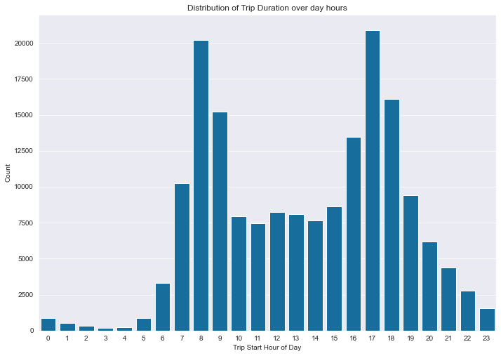

**Observation**

- From the start time hour, the time 8:00 AM and 5:00 PM are the two peak hours which have most bikers, followed by 9:00 AM and 6:00 PM.

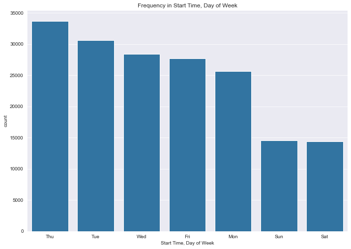

**Observation**

- Thursday has the most bikers with counts of 33,712 of unique values compared to other days.
- However, Saturday has the lowest number of bikers with counts of 14,414 of unique values.

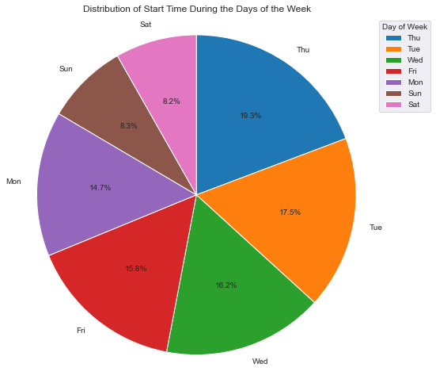

**Observation**

- From the days of the week, Thursday has the most bikers, compared to other days, with a percentage of 19.3%.
- However, Saturday has the lowest number of bikers, with a percentage of 8.2%.

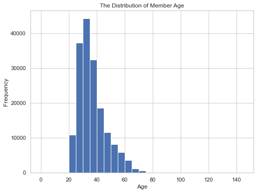

**Observation**

The most bikers are between 25 to 40 years old.

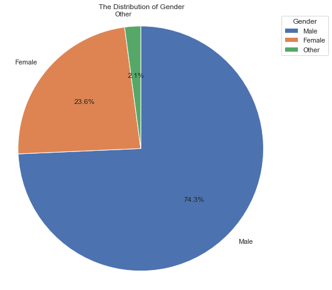

**Observation**

- The male bikers are about three times of female bikers.
- The value counts of "Male", "Female", and "Other" are 126311, 40098, and 3583 respectively.
- However, the percentage of "Male" is approximately 74%, "Female" is approximately 24%, and "Other" is approximately 2% off the "Gender" feature.
- In other words,the number of times a data value occurs or the frequency of "Male" is greater than the frequency of "Female" and "Other" in the "Gender" feature.

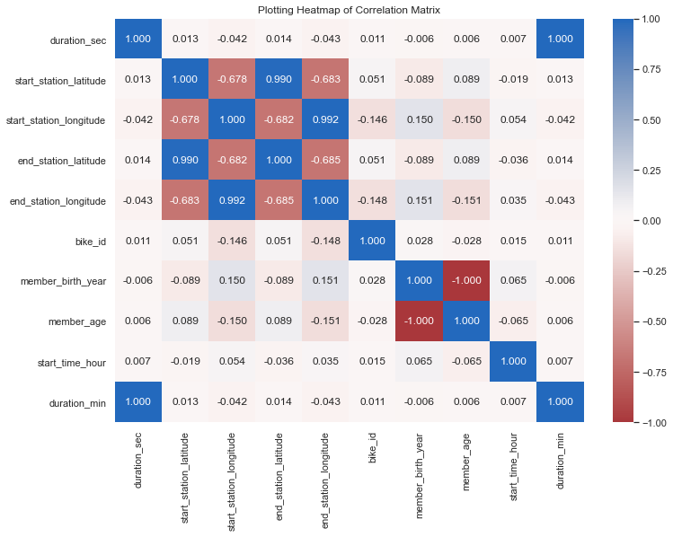

**Observation**

- The blue color with a positive number means positive correlation between the two variables, however, the red color with minus number means negative correlation between the two variables. The stronger the color, the larger the correlation magnitude.
- Start Station Latitute has the highest positive correlation with End Station Latitude.
- Start Station Longitude has the highest positive correlation with End Station Longitude.
- Duration Minutes has the highest positive correlation with Duration Seconds.
- Start Station Latitute has the highest negative correlation with End Station Longitude, followed by Start Station Longitude.
- Start Station Longitude has the highest negative correlation with End Station Latitude, followed by Start Station Latitude.

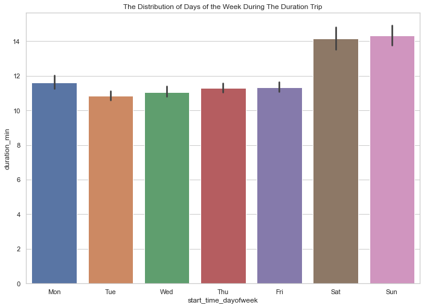

**Observation**

- The weekends (Saturdays and Sundays) are the highest duration trip over the days of the week.

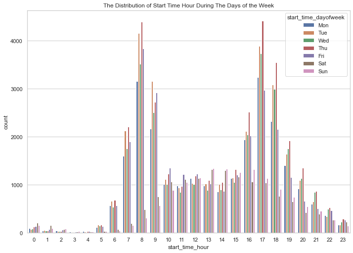

[figure not shown]

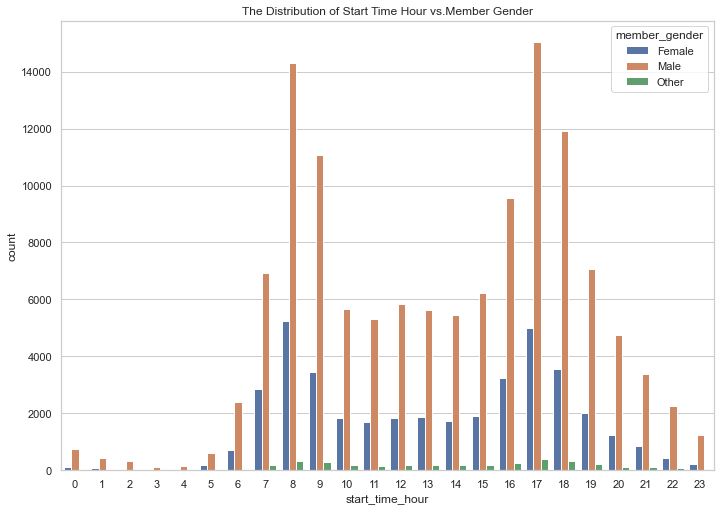

**Observation**

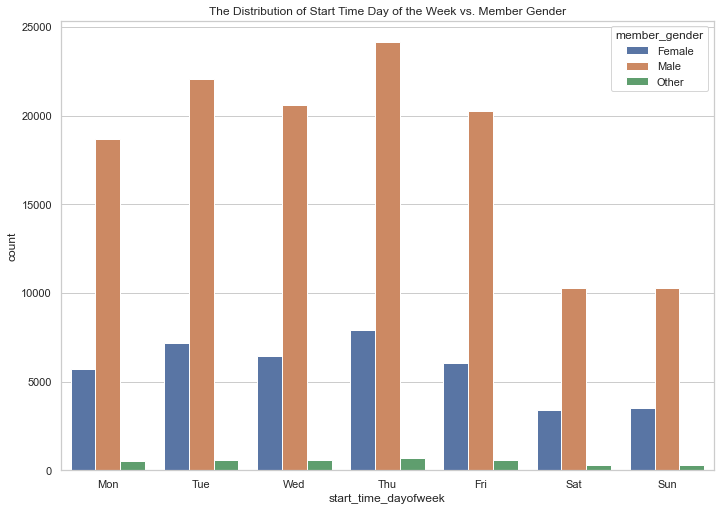

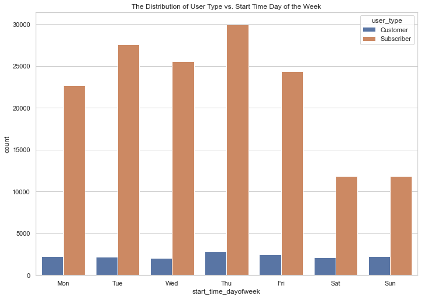